# **Analysis of Injury Causation in the United States**

**Hailey Faith**

Final Tutorial - CMPS6160-01 - Introduction to Data Science - Professor Faust

###### Website link [here](https://haileyfaith3.github.io)

1. Introduction
2. Primary Dataset: Extraction, Transformation, and Load
3. Primary Dataset: Exploratory Data Analysis
4. Secondary Dataset: Extraction, Transformation, and Load
5. Secondary Dataset: Exploratory Data Analysis
6. Probability Model Evaluation
7. Conclusion

# **1. Introduction**

**Background**

Per 100 persons in the United States, about 42.7 are admitted to the emergency room, with about 40 million of those cases injury-related ([CDC](https://www.cdc.gov/nchs/fastats/emergency-department.htm#:~:text=%E2%80%A2Trends%20in%20Emergency)). Additionally, in 2022, the 3rd leading cause of death were by accidental or unintentional injuries alone ([Statista](https://www.statista.com/topics/3991/unintentional-injury-in-the-us/#topicOverview)). Because accidents are extremely unpredictable, knowing how susceptable an individual or loved one might be to injury can better inform their decision-making in situations where they could be injured. For example, it is statistically shown in older women that accidental falls are the leading cause of injury and death ([NIH](https://www.nia.nih.gov/health/falls-and-falls-prevention/older-adults-and-balance-problems)). Knowing this, individuals can better equip themselves within their homes by adding more hand-rails or using walking aids. Are there similar trends with other age or biological sex groups with different injury types? And if so, can I educate those who are more susceptable?

**Goal:**

Overall, I intend to determine what relationships exist between age and/or biological sex with injury mechanism.

**Questions:**

- Given age biological sex, can I predict the likelihood of a given individual going to the ER to have a certain injury?
- Do other factors impact the likelihood of an individual to have a certain injury? For example, does psychological distress (PD) increase the likelihood of individuals to intentionally injure themselves?

**Data Sources**

The first analyzed dataset is "Initial injury-related visits to hospital emergency departments, by sex, age, and intent and mechanism of injury: United States, average annual, selected years 2005–2006 through 2017–2018" taken from the National Hospital Ambulatory Medical Care Survey at the United States National Center for Health Statistics (NHAMICS). The data is based on reporting from a sample of hospital emergency departments in the United States. Variables include age, sex, mechanism of injury, and whether the injury was intentional or not. The analyzed values in this dataset are the complete number of initial injury-related ER visits over 1,000 for ease of computation and visualization.

# **2. Primary Dataset: Extraction, Transformation, and Load**

**Extraction**

The first data set is taken from the [CDC website](https://ftp.cdc.gov/pub/Health_Statistics/NCHS/Publications/Health_US/hus20-21tables/injedvis.xlsx). As mentioned previously, the data is presented as the total number of injury-related ER visits divided by 1000. Each number is organized by age, sex, year, and injury mechanism.

**Load**

For this project, I utilized libraries such as [pandas](https://pandas.pydata.org/pandas-docs/stable/), [numpy](https://numpy.org/doc/), [re](https://docs.python.org/3/library/re.html), and [matplotlib](https://matplotlib.org/stable/users/). This first cell will be importing these libraries.

```python
# Import necessary libraries
import pandas as pd
import re
import numpy as np
import matplotlib.pyplot as plt
```

To load the primary dataset, I utilized pandas' read_excel() function. The raw table (pre-transformation or cleaning) is displayed below.

```python
# Get the data from the CDC website
data = pd.read_excel('https://ftp.cdc.gov/pub/Health_Statistics/NCHS/Publications/Health_US/hus20-21tables/injedvis.xlsx')
data.head()
```

|  | Table InjEDVis. Initial injury-related visits to hospital emergency departments, by sex, age, and intent and mechanism of injury: United States, average annual, selected years 2005–2006 through 2017–2… | Unnamed: 1 | Unnamed: 2 | Unnamed: 3 | Unnamed: 4 | Unnamed: 5 | Unnamed: 6 | Unnamed: 7 | Unnamed: 8 | Unnamed: 9 | ... | Unnamed: 11 | Unnamed: 12 | Unnamed: 13 | Unnamed: 14 | Unnamed: 15 | Unnamed: 16 | Unnamed: 17 | Unnamed: 18 | Unnamed: 19 | Unnamed: 20 |
| --- | --- | --- | --- | --- | --- | --- | --- | --- | --- | --- | --- | --- | --- | --- | --- | --- | --- | --- | --- | --- | --- |
| 0 | Excel version (with more data years and standa... | NaN | NaN | NaN | NaN | NaN | NaN | NaN | NaN | NaN | ... | NaN | NaN | NaN | NaN | NaN | NaN | NaN | NaN | NaN | NaN |
| 1 | [Data are based on reporting by a sample of ho... | NaN | NaN | NaN | NaN | NaN | NaN | NaN | NaN | NaN | ... | NaN | NaN | NaN | NaN | NaN | NaN | NaN | NaN | NaN | NaN |
| 2 | Sex, age, and intent and mechanism of injury\1 | Number of initial injury-related visits (thous... | NaN | NaN | NaN | NaN | NaN | NaN | NaN | NaN | ... | Number of initial injury-related visits per 10... | NaN | NaN | NaN | NaN | NaN | NaN | NaN | NaN | NaN |
| 3 | NaN | 2005–2006 | 2007–2008 | 2008–2009 | 2009–2010 | 2010–2011 | 2011–2012 | 2012–2013 | 2013–2014 | 2014–2015 | ... | 2005–2006 | 2007–2008 | 2008–2009 | 2009–2010 | 2010–2011 | 2011–2012 | 2012–2013 | 2013–2014 | 2014–2015 | 2017–2018 |
| 4 | Both sexes | NaN | NaN | NaN | NaN | NaN | NaN | NaN | NaN | NaN | ... | NaN | NaN | NaN | NaN | NaN | NaN | NaN | NaN | NaN | NaN |

5 rows × 21 columns

**Transformation and Tidying**

When read into pandas above, the data presents itself as extremely untidy. The variables do not have their own designated columns. Instead, each variable presents itself as an observation, which is not a good example of tidy data. Here, I clean up the data and tidy it for more interpretable data analysis.

I began transforming the data by removing the last 10 columns of data, which represents the same data represented in the first 10 rows, but in fraction form. Further, I removed the first two rows, then renamed the column names to have no names. From here, I transposed the data, removed unwanted symbols, and gave the columns their appropriate variable names. Further, I organized the data into variables of year, sex, age, injury type, and number of injuries for efficient data analysis. Finally, I dropped any rows with NaNs because they were not important in any data calculations I had.

First, I removed the latter half of columns that were not needed in my data analysis. These columns displayed the same information in a different fraction formation. I then removed the first two and last three rows because the only information there was supplementary data documentation.

```python
# Remove the latter half of the columns
data = data.drop(data.columns[11:21], axis=1)

# Remove the first 2 rows and last 3 rows because they are all rows with titles
data = data[3:101].reset_index(drop=True)

data.head()
```

|  | Table InjEDVis. Initial injury-related visits to hospital emergency departments, by sex, age, and intent and mechanism of injury: United States, average annual, selected years 2005–2006 through 2017–2… | Unnamed: 1 | Unnamed: 2 | Unnamed: 3 | Unnamed: 4 | Unnamed: 5 | Unnamed: 6 | Unnamed: 7 | Unnamed: 8 | Unnamed: 9 | Unnamed: 10 |
| --- | --- | --- | --- | --- | --- | --- | --- | --- | --- | --- | --- |
| 0 | NaN | 2005–2006 | 2007–2008 | 2008–2009 | 2009–2010 | 2010–2011 | 2011–2012 | 2012–2013 | 2013–2014 | 2014–2015 | 2017–2018 |
| 1 | Both sexes | NaN | NaN | NaN | NaN | NaN | NaN | NaN | NaN | NaN | NaN |
| 2 | All ages, age adjusted\2,\3 | … | … | … | … | … | … | … | … | … | … |
| 3 | All ages, crude\2 | 31706 | 28699 | 31328 | 32204 | 33007 | 31546 | 30402 | 32595 | 33649 | 33025 |
| 4 | Unintentional injuries\4 | 25658 | 23670 | 25725 | 26523 | 27275 | 25955 | 25078 | 27422 | 28849 | 27226 |

Because the title of the entire dataset is labeled as the very first variable and is not needed, I renamed each column to nothing, transposed the data, established new columns indices, then reset the index.

```python
# Rename the columns to nothing
data.rename(columns={'Table InjEDVis. Initial injury-related visits to hospital emergency departments, by sex, age, and intent and mechanism of injury: United States, average annual, selected years 2005–2006 through 2017–2018': '',
                     'Unnamed: 1':'','Unnamed: 2':'','Unnamed: 3':'','Unnamed: 4':'','Unnamed: 5':'',
                     'Unnamed: 6':'','Unnamed: 7':'','Unnamed: 8':'','Unnamed: 9':'','Unnamed: 10':''},
            inplace=True)

# Transpose the data
data = data.T

# Set the first row as the columns indices
data.columns = data.iloc[0]  # Use the first row values as column headers
data = data[1:]               # Remove the first row from the DataFrame

# Reset index
data.reset_index(drop=True, inplace=True)
data.head()
```

|  | NaN | Both sexes | All ages, age adjusted\2,\3 | All ages, crude\2 | Unintentional injuries\4 | Falls | Struck by or against objects or people | Motor vehicle traffic | Cut or pierce | Intentional injuries | ... | Motor vehicle traffic | Cut or pierce | Intentional injuries | 65 years and over\2 | Unintentional injuries\4 | Falls | Struck by or against objects or people | Motor vehicle traffic | Cut or pierce | Intentional injuries |
| --- | --- | --- | --- | --- | --- | --- | --- | --- | --- | --- | --- | --- | --- | --- | --- | --- | --- | --- | --- | --- | --- |
| 0 | 2005–2006 | NaN | … | 31706 | 25658 | 8100 | 2935 | 3714 | 2145 | 1977 | ... | 359 | 158 | 149 | 2155 | 1889 | 1347 | 69 | 139 | *50 | * |
| 1 | 2007–2008 | NaN | … | 28699 | 23670 | 8144 | 2746 | 3387 | 1944 | 1888 | ... | 345 | 163 | 130 | 2193 | 1978 | 1463 | 91 | 116 | *64 | * |
| 2 | 2008–2009 | NaN | … | 31328 | 25725 | 8900 | 2916 | 3508 | 2008 | 2313 | ... | 399 | 190 | 161 | 2294 | 2083 | 1538 | 91 | 146 | *54 | * |
| 3 | 2009–2010 | NaN | … | 32204 | 26523 | 9393 | 3055 | 3622 | 1829 | 2418 | ... | 403 | 159 | 184 | 2322 | 2108 | 1612 | 81 | 134 | *37 | * |
| 4 | 2010–2011 | NaN | … | 33007 | 27275 | 9932 | 3166 | 3557 | 1922 | 2446 | ... | 345 | 157 | 182 | 2582 | 2348 | 1784 | 81 | 124 | *56 | * |

5 rows × 98 columns

Multiple variables/column names have notations such as "\2,\3", "\2", and "\4" that indicate that the data is taken from all initial injury-related visits (including those not included), the data rates are age-adjusted to the year, and the data included unintentional injuries with injury-mechanisms not shown, respectively. Many values included asteriks '*', indicating that their relative squared errors were between 20% and 30%, which needed to be removed for further computation.

```python
# Remove asteriks
data = data.map(lambda x: x.replace('*', '') if isinstance(x, str) else x)

# Clean column names
data.columns = data.columns.str.strip().str.lower().str.replace('\\2,\\3', '')
data.columns = data.columns.str.strip().str.lower().str.replace('\\2', '')
data.columns = data.columns.str.strip().str.lower().str.replace('\\4', '')

data.head()
```

|  | NaN | both sexes | all ages, age adjusted | all ages, crude | unintentional injuries | falls | struck by or against objects or people | motor vehicle traffic | cut or pierce | intentional injuries | ... | motor vehicle traffic | cut or pierce | intentional injuries | 65 years and over | unintentional injuries | falls | struck by or against objects or people | motor vehicle traffic | cut or pierce | intentional injuries |
| --- | --- | --- | --- | --- | --- | --- | --- | --- | --- | --- | --- | --- | --- | --- | --- | --- | --- | --- | --- | --- | --- |
| 0 | 2005–2006 | NaN | … | 31706 | 25658 | 8100 | 2935 | 3714 | 2145 | 1977 | ... | 359 | 158 | 149 | 2155 | 1889 | 1347 | 69 | 139 | 50 |  |
| 1 | 2007–2008 | NaN | … | 28699 | 23670 | 8144 | 2746 | 3387 | 1944 | 1888 | ... | 345 | 163 | 130 | 2193 | 1978 | 1463 | 91 | 116 | 64 |  |
| 2 | 2008–2009 | NaN | … | 31328 | 25725 | 8900 | 2916 | 3508 | 2008 | 2313 | ... | 399 | 190 | 161 | 2294 | 2083 | 1538 | 91 | 146 | 54 |  |
| 3 | 2009–2010 | NaN | … | 32204 | 26523 | 9393 | 3055 | 3622 | 1829 | 2418 | ... | 403 | 159 | 184 | 2322 | 2108 | 1612 | 81 | 134 | 37 |  |
| 4 | 2010–2011 | NaN | … | 33007 | 27275 | 9932 | 3166 | 3557 | 1922 | 2446 | ... | 345 | 157 | 182 | 2582 | 2348 | 1784 | 81 | 124 | 56 |  |

5 rows × 98 columns

Because the first column indicated the year, I renamed that variable to "year".

```python
# Rename the first column to 'year'
data.rename(columns={data.columns[0]: 'year'},inplace=True)
data.head()
```

|  | year | both sexes | all ages, age adjusted | all ages, crude | unintentional injuries | falls | struck by or against objects or people | motor vehicle traffic | cut or pierce | intentional injuries | ... | motor vehicle traffic | cut or pierce | intentional injuries | 65 years and over | unintentional injuries | falls | struck by or against objects or people | motor vehicle traffic | cut or pierce | intentional injuries |
| --- | --- | --- | --- | --- | --- | --- | --- | --- | --- | --- | --- | --- | --- | --- | --- | --- | --- | --- | --- | --- | --- |
| 0 | 2005–2006 | NaN | … | 31706 | 25658 | 8100 | 2935 | 3714 | 2145 | 1977 | ... | 359 | 158 | 149 | 2155 | 1889 | 1347 | 69 | 139 | 50 |  |
| 1 | 2007–2008 | NaN | … | 28699 | 23670 | 8144 | 2746 | 3387 | 1944 | 1888 | ... | 345 | 163 | 130 | 2193 | 1978 | 1463 | 91 | 116 | 64 |  |
| 2 | 2008–2009 | NaN | … | 31328 | 25725 | 8900 | 2916 | 3508 | 2008 | 2313 | ... | 399 | 190 | 161 | 2294 | 2083 | 1538 | 91 | 146 | 54 |  |
| 3 | 2009–2010 | NaN | … | 32204 | 26523 | 9393 | 3055 | 3622 | 1829 | 2418 | ... | 403 | 159 | 184 | 2322 | 2108 | 1612 | 81 | 134 | 37 |  |
| 4 | 2010–2011 | NaN | … | 33007 | 27275 | 9932 | 3166 | 3557 | 1922 | 2446 | ... | 345 | 157 | 182 | 2582 | 2348 | 1784 | 81 | 124 | 56 |  |

5 rows × 98 columns

To generate the variable I wanted, I defined the function "process_injury_data" that would melt and reshape the data. This would keep year, sex, and age in their own columns, but then create a new column called "injury type" that would have each type of injury previously listed as variables themselves. The final column would be the "number of injuries" which are numerical values indicating the number of injuries given the year, sex, age, and injury type.

```python
# Function to process the data for each sex and age group
def process_injury_data(data, sex, age_range, column_range, injury_types):

    # Extract year and injury data for the given sex and age range
    year = data.iloc[:, 0]
    sex_data = data.iloc[:, column_range]
    sex_data = pd.concat([year, sex_data], axis=1)

    # Rename columns and add 'sex' and 'age' columns
    sex_data = sex_data.rename(columns={sex: 'sex'})
    sex_data['sex'] = sex
    sex_data = sex_data.rename(columns={'all ages, crude': 'age'})
    sex_data['age'] = age_range

    # Reshape the data using melt
    sex_data = pd.melt(sex_data, id_vars=['year', 'sex', 'age'],
                       value_vars=injury_types,
                       var_name='injury type',
                       value_name='number of injuries')
    return sex_data
```

For ease of tidying this dataframe, I split the table up by sex: 'both sexes', 'male', and 'female'. Later, I joined each dataframe together to create one large tidy dataframe with all 3 sex categories.

I began by defining the "injury types" and the specific columns where 'both sexes', 'male', and 'female' lie.

```python
# Injury types list
injury_types = ['unintentional injuries', 'falls', 'struck by or against objects or people',
                'motor vehicle traffic', 'cut or pierce', 'intentional injuries']

# Columns for 'both sexes', 'male', and 'female'
both_sexes_cols = range(0, 10)
males_cols = range(10, 54)
females_cols = range(54, 98)
```

I began by processing 'both sexes' by locating the data from the original dataframe and creating a new one called "both_sexes". I then renamed the columns to 'sex' and 'age' and defined object values such as 'both sexes' and 'all ages', respectively.

```python
# Process 'both sexes'
both_sexes = data.iloc[:, both_sexes_cols]
both_sexes = both_sexes.rename(columns={'both sexes': 'sex', 'all ages, crude': 'age'})
both_sexes['sex'] = 'both sexes'
both_sexes['age'] = 'all ages'
both_sexes = pd.melt(both_sexes, id_vars=['year', 'sex', 'age'],
                     value_vars=injury_types,
                     var_name='injury type',
                     value_name='number of injuries')

both_sexes.head()
```

|  | year | sex | age | injury type | number of injuries |
| --- | --- | --- | --- | --- | --- |
| 0 | 2005–2006 | both sexes | all ages | unintentional injuries | 25658 |
| 1 | 2007–2008 | both sexes | all ages | unintentional injuries | 23670 |
| 2 | 2008–2009 | both sexes | all ages | unintentional injuries | 25725 |
| 3 | 2009–2010 | both sexes | all ages | unintentional injuries | 26523 |
| 4 | 2010–2011 | both sexes | all ages | unintentional injuries | 27275 |

Next, I processed the 'male' dataframe by first extracting the age groups from the original dataframe. This includes the age group column, as well as all the columns that come after it until it reaches the next age group. For example, in the 'all ages' column for males, the columns that follow it are 'unintentional injuries', 'falls', 'struck by or against objects or people', 'motor vehicle traffic', 'cut or pierce', and 'intentional injuries'. I then apply the melting function I previously defined to process the male injury data.

```python
# Process 'males' for different age groups
male_age_groups = [('all ages', range(10, 19)),
                   ('under 18 years', range(19, 26)),
                   ('18–24 years', range(26, 33)),
                   ('25-44 years', range(33, 40)),
                   ('45-64 years', range(40, 47)),
                   ('65 years and over', range(47, 54))]

males = pd.concat([process_injury_data(data, 'male', age, cols, injury_types) for age, cols in male_age_groups], axis=0, ignore_index=True)
males.head()
```

|  | year | sex | age | injury type | number of injuries |
| --- | --- | --- | --- | --- | --- |
| 0 | 2005–2006 | male | all ages | unintentional injuries | 13736 |
| 1 | 2007–2008 | male | all ages | unintentional injuries | 12611 |
| 2 | 2008–2009 | male | all ages | unintentional injuries | 13590 |
| 3 | 2009–2010 | male | all ages | unintentional injuries | 14083 |
| 4 | 2010–2011 | male | all ages | unintentional injuries | 14451 |

I followed a similar process as above to process and create the 'female' dataframe by first extracting the age groups from the original dataframe. This includes the age group column, as well as all the columns that come after it until it reaches the next age group. For example, in the 'all ages' column for males, the columns that follow it are 'unintentional injuries', 'falls', 'struck by or against objects or people', 'motor vehicle traffic', 'cut or pierce', and 'intentional injuries'. I then apply the melting function I previously defined to process the female injury data.

```python
# Process 'females' for different age groups
female_age_groups = [('all ages', range(54, 63)),
                     ('under 18 years', range(63, 70)),
                     ('18–24 years', range(70, 77)),
                     ('25-44 years', range(77, 84)),
                     ('45-64 years', range(84, 91)),
                     ('65 years and over', range(91, 98))]

females = pd.concat([process_injury_data(data, 'female', age, cols, injury_types) for age, cols in female_age_groups], axis=0, ignore_index=True)

females.head()
```

|  | year | sex | age | injury type | number of injuries |
| --- | --- | --- | --- | --- | --- |
| 0 | 2005–2006 | female | all ages | unintentional injuries | 11922 |
| 1 | 2007–2008 | female | all ages | unintentional injuries | 11060 |
| 2 | 2008–2009 | female | all ages | unintentional injuries | 12134 |
| 3 | 2009–2010 | female | all ages | unintentional injuries | 12439 |
| 4 | 2010–2011 | female | all ages | unintentional injuries | 12824 |

Finally, I concatinated 'both sexes', 'males', and 'females' to one dataframe which I named "injuries"

```python
# Combine all data (both sexes, males, and females)
injuries = pd.concat([both_sexes, males, females], axis=0, ignore_index=True)
injuries.head()
```

|  | year | sex | age | injury type | number of injuries |
| --- | --- | --- | --- | --- | --- |
| 0 | 2005–2006 | both sexes | all ages | unintentional injuries | 25658 |
| 1 | 2007–2008 | both sexes | all ages | unintentional injuries | 23670 |
| 2 | 2008–2009 | both sexes | all ages | unintentional injuries | 25725 |
| 3 | 2009–2010 | both sexes | all ages | unintentional injuries | 26523 |
| 4 | 2010–2011 | both sexes | all ages | unintentional injuries | 27275 |

For further tidying, I ensured that the all of the values in the 'number of injuries' feature were in numeric form and that there were no NaNs in the entire dataframe.

```python
# Convert 'number of injuries' to numeric
injuries['number of injuries'] = pd.to_numeric(injuries['number of injuries'], errors='coerce')

# Drop any NaNs
injuries.dropna(inplace=True)

# Display the final data
injuries
```

|  | year | sex | age | injury type | number of injuries |
| --- | --- | --- | --- | --- | --- |
| 0 | 2005–2006 | both sexes | all ages | unintentional injuries | 25658.0 |
| 1 | 2007–2008 | both sexes | all ages | unintentional injuries | 23670.0 |
| 2 | 2008–2009 | both sexes | all ages | unintentional injuries | 25725.0 |
| 3 | 2009–2010 | both sexes | all ages | unintentional injuries | 26523.0 |
| 4 | 2010–2011 | both sexes | all ages | unintentional injuries | 27275.0 |
| ... | ... | ... | ... | ... | ... |
| 764 | 2010–2011 | female | 65 years and over | cut or pierce | 56.0 |
| 765 | 2011–2012 | female | 65 years and over | cut or pierce | 72.0 |
| 766 | 2012–2013 | female | 65 years and over | cut or pierce | 54.0 |
| 767 | 2013–2014 | female | 65 years and over | cut or pierce | 44.0 |
| 768 | 2014–2015 | female | 65 years and over | cut or pierce | 69.0 |

755 rows × 5 columns

When I check the data types, all are correct:

```python
injuries.dtypes
```

|  | 0 |
| --- | --- |
| year | object |
| sex | object |
| age | object |
| injury type | object |
| number of injuries | float64 |

**dtype:** object

# **3. Primary Dataset: Exploratory Data Analysis**

From here I can extract data by sex and age. For example, I want to compare females who have been injured from falling at different ages, throughout the years. Most people associated older age with a higher risk of falling. With falling as an injury mechanism, I want to determine if age and falling risk are related. Each graph represented below displays a different injury type.

I began by defining the injury types for easier iteration.

```python
# Define injury types for easy iteration
injury_types = [
    'unintentional injuries',
    'falls',
    'struck by or against objects or people',
    'motor vehicle traffic',
    'cut or pierce',
    'intentional injuries'
]
```

I then created a function called 'filter_data' to reture all of the female data in the dataframe except where the age is 'all ages' since I want to look at each age group, not all of them combined.

```python
# Function to filter the data
def filter_data(injury_type):
    return injuries[(injuries['sex'] == 'female') &
                    (injuries['injury type'] == injury_type) &
                    (injuries['age'] != 'all ages')]
```

Next, I created another function called 'group_data' that grouped the number fo injuries for females by year and age.

```python
# Function to group data by year and age
def group_data(df):
    return df.groupby(['year', 'age'])['number of injuries'].sum().unstack().reindex(columns=['under 18 years', '18–24 years', '25-44 years', '45-64 years', '65 years and over'])
```

Further, I established a dictionary that stored the grouped data as 'grouped_data'.

```python
# Create a dictionary to store the grouped data
grouped_data = {injury_type: group_data(filter_data(injury_type)) for injury_type in injury_types}
```

**Injury Mechanisms Visualizations: Female**

To create plots to display each injury type in females, I defined the plot settings so that the X-axis would be the 'year' column or the index, and the Y-axis would be the 'number of injuries' with each age group as a separate line/color. For easier visualization, I created each injury type into its own subplot. A 'for' loop was used to loop thorugh each injury type to create these subplots.

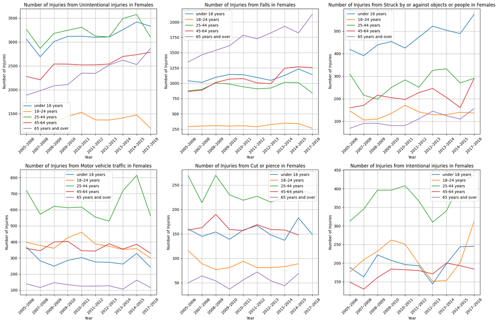

```python
# Define plot settings
x_axis = grouped_data[injury_types[0]].index
y_axis_columns = grouped_data[injury_types[0]].columns

# Plotting function with subplots
fig, axes = plt.subplots(nrows=2, ncols=3, figsize=(18, 12))
axes = axes.flatten() # Flatten the axes array for easier iteration

for i, injury_type in enumerate(injury_types):
    ax = axes[i]
    for column in y_axis_columns:
        y_axis = grouped_data[injury_type][column]
        ax.plot(x_axis, y_axis, label=column)
    ax.set_xlabel('Year')
    ax.set_ylabel('Number of Injuries')
    ax.set_title(f'Number of Injuries from {injury_type.capitalize()} in Females')
    ax.legend()
    ax.grid(True)
    plt.setp(ax.get_xticklabels(), rotation=45)  # Rotate x-axis labels

plt.tight_layout() # Adjust subplot params for a tight layout
plt.show()
```

From the graphics above, I can already observe a few interesting phenomena:

- Females ages 65 and over are more frequently injured from falling.
- Females under 18 years of age are more frequently injured from being struck by or against object or people.
- Females aged between 25 and 44 years are more frequently injured from motor vehicle accidents and being cut or pierce.
- Females aged between 25 and 44 years are more frequently injured from intentional injuries.

It is also interesting to see that there is a trend of elderly females becoming increasingly injured by falling as time has progressed from 2005 to 2018. Looking at the 'falls' graphic, most age groups tend to follow the same position and trend on the graph. However, females ages 18-24 years appear to have the least number of injuries caused by falling.

Additionally, there is a higher number of intentional injuries from females who are age 25-44 years. For all other age groups, intentional injuries were relatively lower and at similar frequencies than those that are 25-44 years. This was an extremely interesting observation that I wanted to dive more into. Therefore, I later brought in a secondary dataset that describes the percentage of US population under serious psychological distress (PD) from the years 1997 to 2016. I was interested in determining a relationship between intentional injuries and PD over time.

Further, I repeated the same EDA process that I used for females in males.

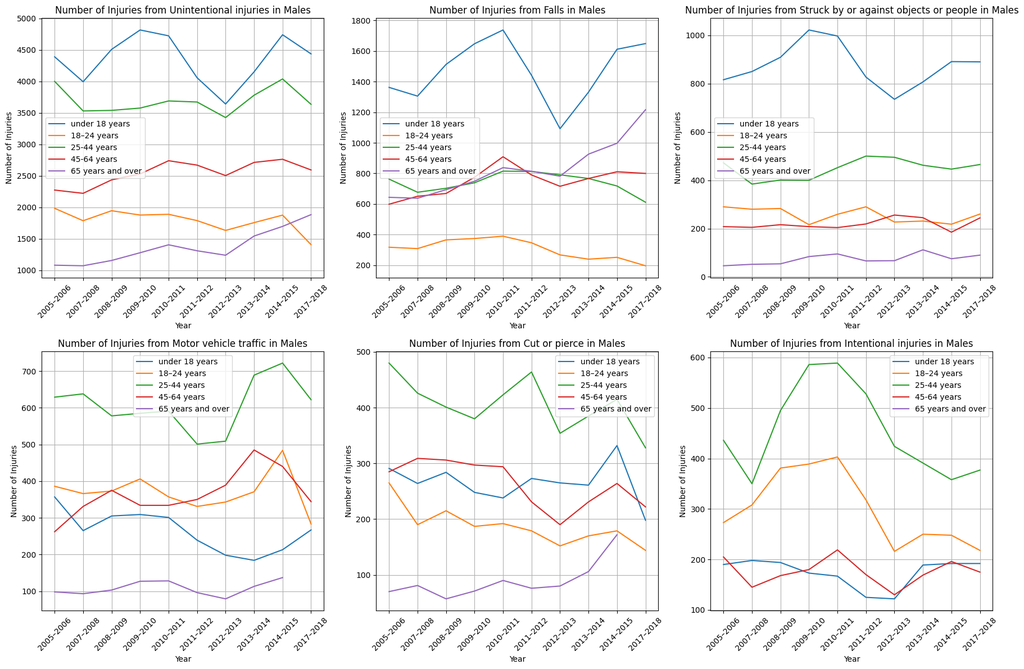

```python
# Function to filter the data
def filter_data(injury_type):
    return injuries[(injuries['sex'] == 'male') &
                    (injuries['injury type'] == injury_type) &
                    (injuries['age'] != 'all ages')]

# Function to group data by year and age
def group_data(df):
    return df.groupby(['year', 'age'])['number of injuries'].sum().unstack().reindex(columns=['under 18 years', '18–24 years', '25-44 years', '45-64 years', '65 years and over'])

# Create a dictionary to store the grouped data
grouped_data = {injury_type: group_data(filter_data(injury_type)) for injury_type in injury_types}

# Define plot settings
x_axis = grouped_data[injury_types[0]].index
y_axis_columns = grouped_data[injury_types[0]].columns

# Plotting function with subplots
fig, axes = plt.subplots(nrows=2, ncols=3, figsize=(18, 12))
axes = axes.flatten() # Flatten the axes array for easier iteration

for i, injury_type in enumerate(injury_types):
    ax = axes[i]
    for column in y_axis_columns:
        y_axis = grouped_data[injury_type][column]
        ax.plot(x_axis, y_axis, label=column)
    ax.set_xlabel('Year')
    ax.set_ylabel('Number of Injuries')
    ax.set_title(f'Number of Injuries from {injury_type.capitalize()} in Males')
    ax.legend()
    ax.grid(True)
    plt.setp(ax.get_xticklabels(), rotation=45)  # Rotate x-axis labels

plt.tight_layout() # Adjust subplot params for a tight layout
plt.show()
```

From the graphics above, I observed some interesting phenomena:

- Males under the age of 18 were more frequently injured by falls and being stuck by or against object or people.
- Males between the ages of 25 and 44 years old were more frequently injured by motor vehicle traffic accidents, being cut or pierce, or intentional harm.

**Fall Comparison: Male vs Female**

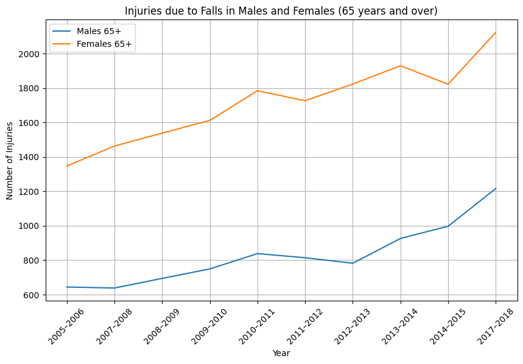

```python
# Filter data for males and females aged 65 and over, with falls as the injury type
males_65_plus_falls = injuries[(injuries['sex'] == 'male') & (injuries['age'] == '65 years and over') & (injuries['injury type'] == 'falls')]
females_65_plus_falls = injuries[(injuries['sex'] == 'female') & (injuries['age'] == '65 years and over') & (injuries['injury type'] == 'falls')]

# Create the plot
plt.figure(figsize=(10, 6))
plt.plot(males_65_plus_falls['year'], males_65_plus_falls['number of injuries'], label='Males 65+')
plt.plot(females_65_plus_falls['year'], females_65_plus_falls['number of injuries'], label='Females 65+')

# Customize the plot
plt.xlabel('Year')
plt.ylabel('Number of Injuries')
plt.title('Injuries due to Falls in Males and Females (65 years and over)')
plt.legend()
plt.grid(True)
plt.xticks(rotation=45)
plt.show()
```

There seems to be an increasing trend in both older males and females of injuries due to falling. However, older females significantly are more frequently injured from falls as compared to older males, which is a well known [statistic](https://www.health.harvard.edu/staying-healthy/why-women-take-the-fall).

Knowing now that intentional injuries were more frequent in men and women who were between the ages of 25 and 44 years, I wanted to compare the the different in frequencies between the two biological sexes.

**Intentional Injuries Comparison: Male vs Female**

I began by filtering the 'injuries' dataframe for males and females aged 25-44 with intentional injuries. After filtering, I created and customized a plot to display the years on the X-axis, number of injuries on the Y-axis, and males and females as different lines and colors.

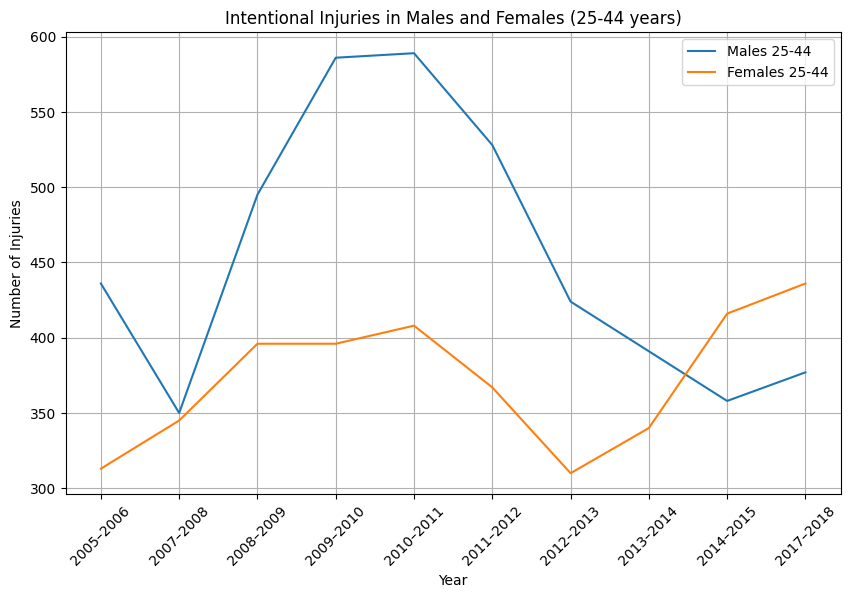

```python
# Filter data for males and females aged 25-44, with intentional injuries
males_25_44_intentional = injuries[(injuries['sex'] == 'male') & (injuries['age'] == '25-44 years') & (injuries['injury type'] == 'intentional injuries')]
females_25_44_intentional = injuries[(injuries['sex'] == 'female') & (injuries['age'] == '25-44 years') & (injuries['injury type'] == 'intentional injuries')]

# Create the plot
plt.figure(figsize=(10, 6))
plt.plot(males_25_44_intentional['year'], males_25_44_intentional['number of injuries'], label='Males 25-44')
plt.plot(females_25_44_intentional['year'], females_25_44_intentional['number of injuries'], label='Females 25-44')

# Customize the plot
plt.xlabel('Year')
plt.ylabel('Number of Injuries')
plt.title('Intentional Injuries in Males and Females (25-44 years)')
plt.legend()
plt.grid(True)
plt.xticks(rotation=45)
plt.show()
```

Based on simple observation, there are no large differences between male and female intentional injuries other than a large peak in male injuries between the years 2008 and 2012. I wanted to understand what external variables might have led to this high frequency of intentional injuries not only in males, but in females as well.

# **3. Secondary Dataset: Extraction, Transformation, and Load**

I brought in a dataset that describes the percentage of US population under serious psychological distress (PD) to determine if there exists a relationship between intentional injury frequency and PD.

I hypothesized that there would be a positive correlation between PD and intentional injuries in both males and females. This would be confirmed by visualizing a higher frequency in PD in individuals who were between 25 and 44 years old.

**Extraction**

**Load**

Similar to the primary dataset, I utilized pandas' read_excel() function to load the secondary dataset. The raw table (pre-transformation or cleaning) is displayed below.

```python
# Get the data from the CDC website
distress = pd.read_excel('https://ftp.cdc.gov/pub/Health_Statistics/NCHS/Publications/Health_US/hus17tables/table046.xlsx')
distress
```

|  | Table 46. Serious psychological distress in the past 30 days among adults aged 18 and over, by selected characteristics: United States, average annual, selected years 1997–1998 through 2015–2016 | Unnamed: 1 | Unnamed: 2 | Unnamed: 3 | Unnamed: 4 | Unnamed: 5 | Unnamed: 6 | Unnamed: 7 | Unnamed: 8 | Unnamed: 9 | ... | Unnamed: 243 | Unnamed: 244 | Unnamed: 245 | Unnamed: 246 | Unnamed: 247 | Unnamed: 248 | Unnamed: 249 | Unnamed: 250 | Unnamed: 251 | Unnamed: 252 |
| --- | --- | --- | --- | --- | --- | --- | --- | --- | --- | --- | --- | --- | --- | --- | --- | --- | --- | --- | --- | --- | --- |
| 0 | Excel version (with more data years and standa... | NaN | NaN | NaN | NaN | NaN | NaN | NaN | NaN | NaN | ... | NaN | NaN | NaN | NaN | NaN | NaN | NaN | NaN | NaN | NaN |
| 1 | [Data are based on household interviews of a s... | NaN | NaN | NaN | NaN | NaN | NaN | NaN | NaN | NaN | ... | NaN | NaN | NaN | NaN | NaN | NaN | NaN | NaN | NaN | NaN |
| 2 | Characteristic | 1997–1998 | SE | 1999–2000 | SE | 2000–2001 | SE | 2001–2002 | SE | 2002–2003 | ... | NaN | NaN | NaN | NaN | NaN | NaN | NaN | NaN | NaN | NaN |
| 3 | NaN | Percent of adults with serious psychological d... | NaN | NaN | NaN | NaN | NaN | NaN | NaN | NaN | ... | NaN | NaN | NaN | NaN | NaN | NaN | NaN | NaN | NaN | NaN |
| 4 | 18 years and over, age-adjusted3/,4/ | 3.2 | 0.1 | 2.6 | 0.1 | 3 | 0.1 | 3.1 | 0.1 | 3.1 | ... | NaN | NaN | NaN | NaN | NaN | NaN | NaN | NaN | NaN | NaN |
| ... | ... | ... | ... | ... | ... | ... | ... | ... | ... | ... | ... | ... | ... | ... | ... | ... | ... | ... | ... | ... | ... |
| 8083 | NaN | NaN | NaN | NaN | NaN | NaN | NaN | NaN | NaN | NaN | ... | NaN | NaN | NaN | NaN | NaN | NaN | NaN | NaN | NaN | NaN |
| 8084 | NaN | NaN | NaN | NaN | NaN | NaN | NaN | NaN | NaN | NaN | ... | NaN | NaN | NaN | NaN | NaN | NaN | NaN | NaN | NaN | NaN |
| 8085 | NaN | NaN | NaN | NaN | NaN | NaN | NaN | NaN | NaN | NaN | ... | NaN | NaN | NaN | NaN | NaN | NaN | NaN | NaN | NaN | NaN |
| 8086 | NaN | NaN | NaN | NaN | NaN | NaN | NaN | NaN | NaN | NaN | ... | NaN | NaN | NaN | NaN | NaN | NaN | NaN | NaN | NaN | NaN |
| 8087 | NaN | NaN | NaN | NaN | NaN | NaN | NaN | NaN | NaN | NaN | ... | NaN | NaN | NaN | NaN | NaN | NaN | NaN | NaN | NaN | 5957.0 |

8088 rows × 253 columns

**Transformation and Tidying**

The last 220 columns of this dataframe are filled with NaNs and are not needed. Additionally, the last 8,068 rows are also not needed. Therefore, I only extracted the columns and rows of data that I will needed

```python
# Extract specific columns and rows in the dataframe
distress = distress.iloc[:19,:33]
distress
```

|  | Table 46. Serious psychological distress in the past 30 days among adults aged 18 and over, by selected characteristics: United States, average annual, selected years 1997–1998 through 2015–2016 | Unnamed: 1 | Unnamed: 2 | Unnamed: 3 | Unnamed: 4 | Unnamed: 5 | Unnamed: 6 | Unnamed: 7 | Unnamed: 8 | Unnamed: 9 | ... | Unnamed: 23 | Unnamed: 24 | Unnamed: 25 | Unnamed: 26 | Unnamed: 27 | Unnamed: 28 | Unnamed: 29 | Unnamed: 30 | Unnamed: 31 | Unnamed: 32 |
| --- | --- | --- | --- | --- | --- | --- | --- | --- | --- | --- | --- | --- | --- | --- | --- | --- | --- | --- | --- | --- | --- |
| 0 | Excel version (with more data years and standa... | NaN | NaN | NaN | NaN | NaN | NaN | NaN | NaN | NaN | ... | NaN | NaN | NaN | NaN | NaN | NaN | NaN | NaN | NaN | NaN |
| 1 | [Data are based on household interviews of a s... | NaN | NaN | NaN | NaN | NaN | NaN | NaN | NaN | NaN | ... | NaN | NaN | NaN | NaN | NaN | NaN | NaN | NaN | NaN | NaN |
| 2 | Characteristic | 1997–1998 | SE | 1999–2000 | SE | 2000–2001 | SE | 2001–2002 | SE | 2002–2003 | ... | 2010–2011 | SE | 2011–2012 | SE | 2013–20141/ | SE | 2014–20151/ | SE | 2015–20161/ | SE |
| 3 | NaN | Percent of adults with serious psychological d... | NaN | NaN | NaN | NaN | NaN | NaN | NaN | NaN | ... | NaN | NaN | NaN | NaN | NaN | NaN | NaN | NaN | NaN | NaN |
| 4 | 18 years and over, age-adjusted3/,4/ | 3.2 | 0.1 | 2.6 | 0.1 | 3 | 0.1 | 3.1 | 0.1 | 3.1 | ... | 3.3 | 0.1 | 3.1 | 0.1 | 3.4 | 0.1 | 3.3 | 0.1 | 3.6 | 0.1 |
| 5 | 18 years and over, crude4/ | 3.2 | 0.1 | 2.6 | 0.1 | 3 | 0.1 | 3.1 | 0.1 | 3.1 | ... | 3.4 | 0.1 | 3.2 | 0.1 | 3.5 | 0.1 | 3.4 | 0.1 | 3.6 | 0.1 |
| 6 | Age | NaN | NaN | NaN | NaN | NaN | NaN | NaN | NaN | NaN | ... | NaN | NaN | NaN | NaN | NaN | NaN | NaN | NaN | NaN | NaN |
| 7 | 18–44 years | 2.9 | 0.1 | 2.3 | 0.1 | 2.7 | 0.1 | 2.9 | 0.1 | 2.9 | ... | 2.9 | 0.1 | 2.8 | 0.1 | 3.1 | 0.1 | 3.3 | 0.1 | 3.5 | 0.2 |
| 8 | 18–24 years | 2.7 | 0.2 | 2.2 | 0.2 | 2.6 | 0.2 | 2.8 | 0.2 | 2.8 | ... | 2.4 | 0.2 | 2.3 | 0.2 | 2.5 | 0.3 | 3.2 | 0.3 | 3.9 | 0.4 |
| 9 | 25–44 years | 3 | 0.1 | 2.4 | 0.1 | 2.8 | 0.1 | 3 | 0.1 | 2.9 | ... | 3.1 | 0.1 | 3 | 0.1 | 3.4 | 0.2 | 3.3 | 0.2 | 3.3 | 0.2 |
| 10 | 45–64 years | 3.7 | 0.1 | 3.2 | 0.2 | 3.6 | 0.2 | 3.9 | 0.2 | 4 | ... | 4.5 | 0.2 | 4.2 | 0.2 | 4.5 | 0.2 | 4.1 | 0.2 | 4.4 | 0.2 |
| 11 | 45–54 years | 3.9 | 0.2 | 3.5 | 0.2 | 3.7 | 0.2 | 4.2 | 0.2 | 4.2 | ... | 4.2 | 0.2 | 4 | 0.2 | 4.6 | 0.2 | 3.9 | 0.2 | 4.5 | 0.3 |
| 12 | 55–64 years | 3.4 | 0.2 | 2.6 | 0.2 | 3.4 | 0.2 | 3.4 | 0.2 | 3.6 | ... | 4.7 | 0.3 | 4.4 | 0.2 | 4.5 | 0.2 | 4.3 | 0.3 | 4.3 | 0.2 |
| 13 | 65 years and over | 3.1 | 0.2 | 2.4 | 0.2 | 2.7 | 0.2 | 2.4 | 0.2 | 2.3 | ... | 2.4 | 0.2 | 2.3 | 0.2 | 2.5 | 0.2 | 2.2 | 0.2 | 2.3 | 0.2 |
| 14 | 65–74 years | 2.5 | 0.2 | 2.3 | 0.2 | 2.8 | 0.2 | 2.4 | 0.2 | 2.3 | ... | 2.6 | 0.2 | 2.5 | 0.2 | 2.7 | 0.2 | 2.4 | 0.2 | 2.4 | 0.2 |
| 15 | 75 years and over | 3.8 | 0.3 | 2.5 | 0.2 | 2.5 | 0.2 | 2.4 | 0.2 | 2.3 | ... | 2.1 | 0.2 | 1.9 | 0.2 | 2.2 | 0.2 | 1.9 | 0.2 | 2.3 | 0.3 |
| 16 | Sex3/ | NaN | NaN | NaN | NaN | NaN | NaN | NaN | NaN | NaN | ... | NaN | NaN | NaN | NaN | NaN | NaN | NaN | NaN | NaN | NaN |
| 17 | Male | 2.5 | 0.1 | 2 | 0.1 | 2.4 | 0.1 | 2.4 | 0.1 | 2.3 | ... | 2.8 | 0.1 | 2.5 | 0.1 | 2.9 | 0.1 | 2.7 | 0.1 | 2.9 | 0.1 |
| 18 | Female | 3.8 | 0.1 | 3.1 | 0.1 | 3.5 | 0.1 | 3.8 | 0.1 | 3.9 | ... | 3.7 | 0.1 | 3.7 | 0.1 | 3.9 | 0.1 | 3.9 | 0.1 | 4.2 | 0.2 |

19 rows × 33 columns

The first two rows are empty rows with titles that are not needed, so I removed those. Additionally, I renamed all of the column variables to nothing for ease of reindexing and transposing.

```python
# Remove the first 2 rows because they are all rows with titles
distress = distress.iloc[2:].reset_index(drop=True)

# Rename the columns to nothing
distress.rename(columns={'Table 46. Serious psychological distress in the past 30 days among adults aged 18 and over, by selected characteristics: United States, average annual, selected years 1997–1998 through 2015–2016': '',
                     'Unnamed: 1':'','Unnamed: 2':'','Unnamed: 3':'','Unnamed: 4':'','Unnamed: 5':'',
                     'Unnamed: 6':'','Unnamed: 7':'','Unnamed: 8':'','Unnamed: 9':'','Unnamed: 10':'',
                       'Unnamed: 11':'','Unnamed: 12':'','Unnamed: 13':'','Unnamed: 14':'','Unnamed: 15':'',
                       'Unnamed: 16':'','Unnamed: 17':'','Unnamed: 18':'','Unnamed: 19':'','Unnamed: 20':'','Unnamed: 21':'',
                       'Unnamed: 22':'','Unnamed: 23':'','Unnamed: 24':'','Unnamed: 25':'','Unnamed: 26':'','Unnamed: 27':'',
                       'Unnamed: 28':'','Unnamed: 29':'','Unnamed: 30':'','Unnamed: 31':'','Unnamed: 32':''},
            inplace=True)

distress.head()
```

|  |  |  |  |  |  |  |  |  |  |  | ... |  |  |  |  |  |  |  |  |  |  |
| --- | --- | --- | --- | --- | --- | --- | --- | --- | --- | --- | --- | --- | --- | --- | --- | --- | --- | --- | --- | --- | --- |
| 0 | Characteristic | 1997–1998 | SE | 1999–2000 | SE | 2000–2001 | SE | 2001–2002 | SE | 2002–2003 | ... | 2010–2011 | SE | 2011–2012 | SE | 2013–20141/ | SE | 2014–20151/ | SE | 2015–20161/ | SE |
| 1 | NaN | Percent of adults with serious psychological d... | NaN | NaN | NaN | NaN | NaN | NaN | NaN | NaN | ... | NaN | NaN | NaN | NaN | NaN | NaN | NaN | NaN | NaN | NaN |
| 2 | 18 years and over, age-adjusted3/,4/ | 3.2 | 0.1 | 2.6 | 0.1 | 3 | 0.1 | 3.1 | 0.1 | 3.1 | ... | 3.3 | 0.1 | 3.1 | 0.1 | 3.4 | 0.1 | 3.3 | 0.1 | 3.6 | 0.1 |
| 3 | 18 years and over, crude4/ | 3.2 | 0.1 | 2.6 | 0.1 | 3 | 0.1 | 3.1 | 0.1 | 3.1 | ... | 3.4 | 0.1 | 3.2 | 0.1 | 3.5 | 0.1 | 3.4 | 0.1 | 3.6 | 0.1 |
| 4 | Age | NaN | NaN | NaN | NaN | NaN | NaN | NaN | NaN | NaN | ... | NaN | NaN | NaN | NaN | NaN | NaN | NaN | NaN | NaN | NaN |

5 rows × 33 columns

Next, I transposed the data so it is in shape for better tidying.

```python
# Transpose the data
distress = distress.T
distress
```

|  | 0 | 1 | 2 | 3 | 4 | 5 | 6 | 7 | 8 | 9 | 10 | 11 | 12 | 13 | 14 | 15 | 16 |
| --- | --- | --- | --- | --- | --- | --- | --- | --- | --- | --- | --- | --- | --- | --- | --- | --- | --- |
|  | Characteristic | NaN | 18 years and over, age-adjusted3/,4/ | 18 years and over, crude4/ | Age | 18–44 years | 18–24 years | 25–44 years | 45–64 years | 45–54 years | 55–64 years | 65 years and over | 65–74 years | 75 years and over | Sex3/ | Male | Female |
|  | 1997–1998 | Percent of adults with serious psychological d... | 3.2 | 3.2 | NaN | 2.9 | 2.7 | 3 | 3.7 | 3.9 | 3.4 | 3.1 | 2.5 | 3.8 | NaN | 2.5 | 3.8 |
|  | SE | NaN | 0.1 | 0.1 | NaN | 0.1 | 0.2 | 0.1 | 0.1 | 0.2 | 0.2 | 0.2 | 0.2 | 0.3 | NaN | 0.1 | 0.1 |
|  | 1999–2000 | NaN | 2.6 | 2.6 | NaN | 2.3 | 2.2 | 2.4 | 3.2 | 3.5 | 2.6 | 2.4 | 2.3 | 2.5 | NaN | 2 | 3.1 |
|  | SE | NaN | 0.1 | 0.1 | NaN | 0.1 | 0.2 | 0.1 | 0.2 | 0.2 | 0.2 | 0.2 | 0.2 | 0.2 | NaN | 0.1 | 0.1 |
|  | 2000–2001 | NaN | 3 | 3 | NaN | 2.7 | 2.6 | 2.8 | 3.6 | 3.7 | 3.4 | 2.7 | 2.8 | 2.5 | NaN | 2.4 | 3.5 |
|  | SE | NaN | 0.1 | 0.1 | NaN | 0.1 | 0.2 | 0.1 | 0.2 | 0.2 | 0.2 | 0.2 | 0.2 | 0.2 | NaN | 0.1 | 0.1 |
|  | 2001–2002 | NaN | 3.1 | 3.1 | NaN | 2.9 | 2.8 | 3 | 3.9 | 4.2 | 3.4 | 2.4 | 2.4 | 2.4 | NaN | 2.4 | 3.8 |
|  | SE | NaN | 0.1 | 0.1 | NaN | 0.1 | 0.2 | 0.1 | 0.2 | 0.2 | 0.2 | 0.2 | 0.2 | 0.2 | NaN | 0.1 | 0.1 |
|  | 2002–2003 | NaN | 3.1 | 3.1 | NaN | 2.9 | 2.8 | 2.9 | 4 | 4.2 | 3.6 | 2.3 | 2.3 | 2.3 | NaN | 2.3 | 3.9 |
|  | SE | NaN | 0.1 | 0.1 | NaN | 0.1 | 0.2 | 0.1 | 0.2 | 0.2 | 0.2 | 0.2 | 0.2 | 0.2 | NaN | 0.1 | 0.1 |
|  | 2003–2004 | NaN | 3.1 | 3.1 | NaN | 2.9 | 2.8 | 2.9 | 3.9 | 3.9 | 3.9 | 2.4 | 2.3 | 2.5 | NaN | 2.3 | 3.9 |
|  | SE | NaN | 0.1 | 0.1 | NaN | 0.1 | 0.2 | 0.1 | 0.2 | 0.2 | 0.3 | 0.2 | 0.2 | 0.3 | NaN | 0.1 | 0.1 |
|  | 2004–2005 | NaN | 3 | 3 | NaN | 2.8 | 2.5 | 2.9 | 3.7 | 3.9 | 3.4 | 2.5 | 2.2 | 2.9 | NaN | 2.3 | 3.7 |
|  | SE | NaN | 0.1 | 0.1 | NaN | 0.1 | 0.2 | 0.1 | 0.2 | 0.2 | 0.2 | 0.2 | 0.2 | 0.3 | NaN | 0.1 | 0.1 |
|  | 2006–2007 | NaN | 2.8 | 2.9 | NaN | 2.5 | 2 | 2.7 | 3.7 | 3.7 | 3.8 | 2.1 | 2.1 | 2 | NaN | 2.1 | 3.4 |
|  | SE | NaN | 0.1 | 0.1 | NaN | 0.1 | 0.3 | 0.1 | 0.2 | 0.2 | 0.3 | 0.2 | 0.2 | 0.2 | NaN | 0.1 | 0.1 |
|  | 2007–2008 | NaN | 2.9 | 2.9 | NaN | 2.7 | 2.3 | 2.8 | 3.6 | 3.6 | 3.6 | 2.4 | 2.4 | 2.4 | NaN | 2.2 | 3.5 |
|  | SE | NaN | 0.1 | 0.1 | NaN | 0.1 | 0.3 | 0.2 | 0.2 | 0.3 | 0.3 | 0.2 | 0.3 | 0.3 | NaN | 0.1 | 0.1 |
|  | 2008–2009 | NaN | 3.2 | 3.2 | NaN | 3.1 | 2.5 | 3.3 | 3.7 | 3.9 | 3.6 | 2.4 | 2.2 | 2.6 | NaN | 2.7 | 3.6 |
|  | SE | NaN | 0.1 | 0.1 | NaN | 0.2 | 0.3 | 0.2 | 0.2 | 0.2 | 0.2 | 0.2 | 0.2 | 0.3 | NaN | 0.1 | 0.1 |
|  | 2009–2010 | NaN | 3.2 | 3.3 | NaN | 3.1 | 2.4 | 3.4 | 4.1 | 4.1 | 4 | 2.1 | 2 | 2.3 | NaN | 2.8 | 3.7 |
|  | SE | NaN | 0.1 | 0.1 | NaN | 0.1 | 0.3 | 0.2 | 0.2 | 0.2 | 0.3 | 0.2 | 0.2 | 0.2 | NaN | 0.1 | 0.1 |
|  | 2010–2011 | NaN | 3.3 | 3.4 | NaN | 2.9 | 2.4 | 3.1 | 4.5 | 4.2 | 4.7 | 2.4 | 2.6 | 2.1 | NaN | 2.8 | 3.7 |
|  | SE | NaN | 0.1 | 0.1 | NaN | 0.1 | 0.2 | 0.1 | 0.2 | 0.2 | 0.3 | 0.2 | 0.2 | 0.2 | NaN | 0.1 | 0.1 |
|  | 2011–2012 | NaN | 3.1 | 3.2 | NaN | 2.8 | 2.3 | 3 | 4.2 | 4 | 4.4 | 2.3 | 2.5 | 1.9 | NaN | 2.5 | 3.7 |
|  | SE | NaN | 0.1 | 0.1 | NaN | 0.1 | 0.2 | 0.1 | 0.2 | 0.2 | 0.2 | 0.2 | 0.2 | 0.2 | NaN | 0.1 | 0.1 |
|  | 2013–20141/ | NaN | 3.4 | 3.5 | NaN | 3.1 | 2.5 | 3.4 | 4.5 | 4.6 | 4.5 | 2.5 | 2.7 | 2.2 | NaN | 2.9 | 3.9 |
|  | SE | NaN | 0.1 | 0.1 | NaN | 0.1 | 0.3 | 0.2 | 0.2 | 0.2 | 0.2 | 0.2 | 0.2 | 0.2 | NaN | 0.1 | 0.1 |
|  | 2014–20151/ | NaN | 3.3 | 3.4 | NaN | 3.3 | 3.2 | 3.3 | 4.1 | 3.9 | 4.3 | 2.2 | 2.4 | 1.9 | NaN | 2.7 | 3.9 |
|  | SE | NaN | 0.1 | 0.1 | NaN | 0.1 | 0.3 | 0.2 | 0.2 | 0.2 | 0.3 | 0.2 | 0.2 | 0.2 | NaN | 0.1 | 0.1 |
|  | 2015–20161/ | NaN | 3.6 | 3.6 | NaN | 3.5 | 3.9 | 3.3 | 4.4 | 4.5 | 4.3 | 2.3 | 2.4 | 2.3 | NaN | 2.9 | 4.2 |
|  | SE | NaN | 0.1 | 0.1 | NaN | 0.2 | 0.4 | 0.2 | 0.2 | 0.3 | 0.2 | 0.2 | 0.2 | 0.3 | NaN | 0.1 | 0.2 |

Because I do not need to know the stardard error, or 'SE', I removed those rows by removing the rows where all of the values in the '0' index column were repeated.

```python
distress = distress[~distress[0].duplicated(keep=False)]
distress
```

|  | 0 | 1 | 2 | 3 | 4 | 5 | 6 | 7 | 8 | 9 | 10 | 11 | 12 | 13 | 14 | 15 | 16 |
| --- | --- | --- | --- | --- | --- | --- | --- | --- | --- | --- | --- | --- | --- | --- | --- | --- | --- |
|  | Characteristic | NaN | 18 years and over, age-adjusted3/,4/ | 18 years and over, crude4/ | Age | 18–44 years | 18–24 years | 25–44 years | 45–64 years | 45–54 years | 55–64 years | 65 years and over | 65–74 years | 75 years and over | Sex3/ | Male | Female |
|  | 1997–1998 | Percent of adults with serious psychological d... | 3.2 | 3.2 | NaN | 2.9 | 2.7 | 3 | 3.7 | 3.9 | 3.4 | 3.1 | 2.5 | 3.8 | NaN | 2.5 | 3.8 |
|  | 1999–2000 | NaN | 2.6 | 2.6 | NaN | 2.3 | 2.2 | 2.4 | 3.2 | 3.5 | 2.6 | 2.4 | 2.3 | 2.5 | NaN | 2 | 3.1 |
|  | 2000–2001 | NaN | 3 | 3 | NaN | 2.7 | 2.6 | 2.8 | 3.6 | 3.7 | 3.4 | 2.7 | 2.8 | 2.5 | NaN | 2.4 | 3.5 |
|  | 2001–2002 | NaN | 3.1 | 3.1 | NaN | 2.9 | 2.8 | 3 | 3.9 | 4.2 | 3.4 | 2.4 | 2.4 | 2.4 | NaN | 2.4 | 3.8 |
|  | 2002–2003 | NaN | 3.1 | 3.1 | NaN | 2.9 | 2.8 | 2.9 | 4 | 4.2 | 3.6 | 2.3 | 2.3 | 2.3 | NaN | 2.3 | 3.9 |
|  | 2003–2004 | NaN | 3.1 | 3.1 | NaN | 2.9 | 2.8 | 2.9 | 3.9 | 3.9 | 3.9 | 2.4 | 2.3 | 2.5 | NaN | 2.3 | 3.9 |
|  | 2004–2005 | NaN | 3 | 3 | NaN | 2.8 | 2.5 | 2.9 | 3.7 | 3.9 | 3.4 | 2.5 | 2.2 | 2.9 | NaN | 2.3 | 3.7 |
|  | 2006–2007 | NaN | 2.8 | 2.9 | NaN | 2.5 | 2 | 2.7 | 3.7 | 3.7 | 3.8 | 2.1 | 2.1 | 2 | NaN | 2.1 | 3.4 |
|  | 2007–2008 | NaN | 2.9 | 2.9 | NaN | 2.7 | 2.3 | 2.8 | 3.6 | 3.6 | 3.6 | 2.4 | 2.4 | 2.4 | NaN | 2.2 | 3.5 |
|  | 2008–2009 | NaN | 3.2 | 3.2 | NaN | 3.1 | 2.5 | 3.3 | 3.7 | 3.9 | 3.6 | 2.4 | 2.2 | 2.6 | NaN | 2.7 | 3.6 |
|  | 2009–2010 | NaN | 3.2 | 3.3 | NaN | 3.1 | 2.4 | 3.4 | 4.1 | 4.1 | 4 | 2.1 | 2 | 2.3 | NaN | 2.8 | 3.7 |
|  | 2010–2011 | NaN | 3.3 | 3.4 | NaN | 2.9 | 2.4 | 3.1 | 4.5 | 4.2 | 4.7 | 2.4 | 2.6 | 2.1 | NaN | 2.8 | 3.7 |
|  | 2011–2012 | NaN | 3.1 | 3.2 | NaN | 2.8 | 2.3 | 3 | 4.2 | 4 | 4.4 | 2.3 | 2.5 | 1.9 | NaN | 2.5 | 3.7 |
|  | 2013–20141/ | NaN | 3.4 | 3.5 | NaN | 3.1 | 2.5 | 3.4 | 4.5 | 4.6 | 4.5 | 2.5 | 2.7 | 2.2 | NaN | 2.9 | 3.9 |
|  | 2014–20151/ | NaN | 3.3 | 3.4 | NaN | 3.3 | 3.2 | 3.3 | 4.1 | 3.9 | 4.3 | 2.2 | 2.4 | 1.9 | NaN | 2.7 | 3.9 |
|  | 2015–20161/ | NaN | 3.6 | 3.6 | NaN | 3.5 | 3.9 | 3.3 | 4.4 | 4.5 | 4.3 | 2.3 | 2.4 | 2.3 | NaN | 2.9 | 4.2 |

I next reset the row index.

```python
# Reset index
distress.reset_index(drop=True, inplace=True)
distress
```

|  | 0 | 1 | 2 | 3 | 4 | 5 | 6 | 7 | 8 | 9 | 10 | 11 | 12 | 13 | 14 | 15 | 16 |
| --- | --- | --- | --- | --- | --- | --- | --- | --- | --- | --- | --- | --- | --- | --- | --- | --- | --- |
| 0 | Characteristic | NaN | 18 years and over, age-adjusted3/,4/ | 18 years and over, crude4/ | Age | 18–44 years | 18–24 years | 25–44 years | 45–64 years | 45–54 years | 55–64 years | 65 years and over | 65–74 years | 75 years and over | Sex3/ | Male | Female |
| 1 | 1997–1998 | Percent of adults with serious psychological d... | 3.2 | 3.2 | NaN | 2.9 | 2.7 | 3 | 3.7 | 3.9 | 3.4 | 3.1 | 2.5 | 3.8 | NaN | 2.5 | 3.8 |
| 2 | 1999–2000 | NaN | 2.6 | 2.6 | NaN | 2.3 | 2.2 | 2.4 | 3.2 | 3.5 | 2.6 | 2.4 | 2.3 | 2.5 | NaN | 2 | 3.1 |
| 3 | 2000–2001 | NaN | 3 | 3 | NaN | 2.7 | 2.6 | 2.8 | 3.6 | 3.7 | 3.4 | 2.7 | 2.8 | 2.5 | NaN | 2.4 | 3.5 |
| 4 | 2001–2002 | NaN | 3.1 | 3.1 | NaN | 2.9 | 2.8 | 3 | 3.9 | 4.2 | 3.4 | 2.4 | 2.4 | 2.4 | NaN | 2.4 | 3.8 |
| 5 | 2002–2003 | NaN | 3.1 | 3.1 | NaN | 2.9 | 2.8 | 2.9 | 4 | 4.2 | 3.6 | 2.3 | 2.3 | 2.3 | NaN | 2.3 | 3.9 |
| 6 | 2003–2004 | NaN | 3.1 | 3.1 | NaN | 2.9 | 2.8 | 2.9 | 3.9 | 3.9 | 3.9 | 2.4 | 2.3 | 2.5 | NaN | 2.3 | 3.9 |
| 7 | 2004–2005 | NaN | 3 | 3 | NaN | 2.8 | 2.5 | 2.9 | 3.7 | 3.9 | 3.4 | 2.5 | 2.2 | 2.9 | NaN | 2.3 | 3.7 |
| 8 | 2006–2007 | NaN | 2.8 | 2.9 | NaN | 2.5 | 2 | 2.7 | 3.7 | 3.7 | 3.8 | 2.1 | 2.1 | 2 | NaN | 2.1 | 3.4 |
| 9 | 2007–2008 | NaN | 2.9 | 2.9 | NaN | 2.7 | 2.3 | 2.8 | 3.6 | 3.6 | 3.6 | 2.4 | 2.4 | 2.4 | NaN | 2.2 | 3.5 |
| 10 | 2008–2009 | NaN | 3.2 | 3.2 | NaN | 3.1 | 2.5 | 3.3 | 3.7 | 3.9 | 3.6 | 2.4 | 2.2 | 2.6 | NaN | 2.7 | 3.6 |
| 11 | 2009–2010 | NaN | 3.2 | 3.3 | NaN | 3.1 | 2.4 | 3.4 | 4.1 | 4.1 | 4 | 2.1 | 2 | 2.3 | NaN | 2.8 | 3.7 |
| 12 | 2010–2011 | NaN | 3.3 | 3.4 | NaN | 2.9 | 2.4 | 3.1 | 4.5 | 4.2 | 4.7 | 2.4 | 2.6 | 2.1 | NaN | 2.8 | 3.7 |
| 13 | 2011–2012 | NaN | 3.1 | 3.2 | NaN | 2.8 | 2.3 | 3 | 4.2 | 4 | 4.4 | 2.3 | 2.5 | 1.9 | NaN | 2.5 | 3.7 |
| 14 | 2013–20141/ | NaN | 3.4 | 3.5 | NaN | 3.1 | 2.5 | 3.4 | 4.5 | 4.6 | 4.5 | 2.5 | 2.7 | 2.2 | NaN | 2.9 | 3.9 |
| 15 | 2014–20151/ | NaN | 3.3 | 3.4 | NaN | 3.3 | 3.2 | 3.3 | 4.1 | 3.9 | 4.3 | 2.2 | 2.4 | 1.9 | NaN | 2.7 | 3.9 |
| 16 | 2015–20161/ | NaN | 3.6 | 3.6 | NaN | 3.5 | 3.9 | 3.3 | 4.4 | 4.5 | 4.3 | 2.3 | 2.4 | 2.3 | NaN | 2.9 | 4.2 |

To clean up the data, I needed to remove any unwanted notations what might exist in one of the 'year' values or column variables.

```python
replacements = ['1/', '3/,4/', '3/', '4/', ', crude']
for replacement in replacements:
    distress = distress.map(lambda x: x.replace(replacement, '') if isinstance(x, str) else x)
distress
```

|  | 0 | 1 | 2 | 3 | 4 | 5 | 6 | 7 | 8 | 9 | 10 | 11 | 12 | 13 | 14 | 15 | 16 |
| --- | --- | --- | --- | --- | --- | --- | --- | --- | --- | --- | --- | --- | --- | --- | --- | --- | --- |
| 0 | Characteristic | NaN | 18 years and over, age-adjusted | 18 years and over | Age | 18–44 years | 18–24 years | 25–44 years | 45–64 years | 45–54 years | 55–64 years | 65 years and over | 65–74 years | 75 years and over | Sex | Male | Female |
| 1 | 1997–1998 | Percent of adults with serious psychological d... | 3.2 | 3.2 | NaN | 2.9 | 2.7 | 3 | 3.7 | 3.9 | 3.4 | 3.1 | 2.5 | 3.8 | NaN | 2.5 | 3.8 |
| 2 | 1999–2000 | NaN | 2.6 | 2.6 | NaN | 2.3 | 2.2 | 2.4 | 3.2 | 3.5 | 2.6 | 2.4 | 2.3 | 2.5 | NaN | 2 | 3.1 |
| 3 | 2000–2001 | NaN | 3 | 3 | NaN | 2.7 | 2.6 | 2.8 | 3.6 | 3.7 | 3.4 | 2.7 | 2.8 | 2.5 | NaN | 2.4 | 3.5 |
| 4 | 2001–2002 | NaN | 3.1 | 3.1 | NaN | 2.9 | 2.8 | 3 | 3.9 | 4.2 | 3.4 | 2.4 | 2.4 | 2.4 | NaN | 2.4 | 3.8 |
| 5 | 2002–2003 | NaN | 3.1 | 3.1 | NaN | 2.9 | 2.8 | 2.9 | 4 | 4.2 | 3.6 | 2.3 | 2.3 | 2.3 | NaN | 2.3 | 3.9 |
| 6 | 2003–2004 | NaN | 3.1 | 3.1 | NaN | 2.9 | 2.8 | 2.9 | 3.9 | 3.9 | 3.9 | 2.4 | 2.3 | 2.5 | NaN | 2.3 | 3.9 |
| 7 | 2004–2005 | NaN | 3 | 3 | NaN | 2.8 | 2.5 | 2.9 | 3.7 | 3.9 | 3.4 | 2.5 | 2.2 | 2.9 | NaN | 2.3 | 3.7 |
| 8 | 2006–2007 | NaN | 2.8 | 2.9 | NaN | 2.5 | 2 | 2.7 | 3.7 | 3.7 | 3.8 | 2.1 | 2.1 | 2 | NaN | 2.1 | 3.4 |
| 9 | 2007–2008 | NaN | 2.9 | 2.9 | NaN | 2.7 | 2.3 | 2.8 | 3.6 | 3.6 | 3.6 | 2.4 | 2.4 | 2.4 | NaN | 2.2 | 3.5 |
| 10 | 2008–2009 | NaN | 3.2 | 3.2 | NaN | 3.1 | 2.5 | 3.3 | 3.7 | 3.9 | 3.6 | 2.4 | 2.2 | 2.6 | NaN | 2.7 | 3.6 |
| 11 | 2009–2010 | NaN | 3.2 | 3.3 | NaN | 3.1 | 2.4 | 3.4 | 4.1 | 4.1 | 4 | 2.1 | 2 | 2.3 | NaN | 2.8 | 3.7 |
| 12 | 2010–2011 | NaN | 3.3 | 3.4 | NaN | 2.9 | 2.4 | 3.1 | 4.5 | 4.2 | 4.7 | 2.4 | 2.6 | 2.1 | NaN | 2.8 | 3.7 |
| 13 | 2011–2012 | NaN | 3.1 | 3.2 | NaN | 2.8 | 2.3 | 3 | 4.2 | 4 | 4.4 | 2.3 | 2.5 | 1.9 | NaN | 2.5 | 3.7 |
| 14 | 2013–2014 | NaN | 3.4 | 3.5 | NaN | 3.1 | 2.5 | 3.4 | 4.5 | 4.6 | 4.5 | 2.5 | 2.7 | 2.2 | NaN | 2.9 | 3.9 |
| 15 | 2014–2015 | NaN | 3.3 | 3.4 | NaN | 3.3 | 3.2 | 3.3 | 4.1 | 3.9 | 4.3 | 2.2 | 2.4 | 1.9 | NaN | 2.7 | 3.9 |
| 16 | 2015–2016 | NaN | 3.6 | 3.6 | NaN | 3.5 | 3.9 | 3.3 | 4.4 | 4.5 | 4.3 | 2.3 | 2.4 | 2.3 | NaN | 2.9 | 4.2 |

There are a few columns that included only NaNs that were not important for computation, or the age groups were not needed, including '18 years and over, age-adjusted', '18 years and over', '65–74 years', and '75 years and over'. Therefore, I dropped these columns.

```python
columns_to_remove = [1, 2, 3, 4, 5, 8, 12, 13, 14]
distress = distress.drop(columns=columns_to_remove)
distress
```

|  | 0 | 6 | 7 | 9 | 10 | 11 | 15 | 16 |
| --- | --- | --- | --- | --- | --- | --- | --- | --- |
| 0 | Characteristic | 18–24 years | 25–44 years | 45–54 years | 55–64 years | 65 years and over | Male | Female |
| 1 | 1997–1998 | 2.7 | 3 | 3.9 | 3.4 | 3.1 | 2.5 | 3.8 |
| 2 | 1999–2000 | 2.2 | 2.4 | 3.5 | 2.6 | 2.4 | 2 | 3.1 |
| 3 | 2000–2001 | 2.6 | 2.8 | 3.7 | 3.4 | 2.7 | 2.4 | 3.5 |
| 4 | 2001–2002 | 2.8 | 3 | 4.2 | 3.4 | 2.4 | 2.4 | 3.8 |
| 5 | 2002–2003 | 2.8 | 2.9 | 4.2 | 3.6 | 2.3 | 2.3 | 3.9 |
| 6 | 2003–2004 | 2.8 | 2.9 | 3.9 | 3.9 | 2.4 | 2.3 | 3.9 |
| 7 | 2004–2005 | 2.5 | 2.9 | 3.9 | 3.4 | 2.5 | 2.3 | 3.7 |
| 8 | 2006–2007 | 2 | 2.7 | 3.7 | 3.8 | 2.1 | 2.1 | 3.4 |
| 9 | 2007–2008 | 2.3 | 2.8 | 3.6 | 3.6 | 2.4 | 2.2 | 3.5 |
| 10 | 2008–2009 | 2.5 | 3.3 | 3.9 | 3.6 | 2.4 | 2.7 | 3.6 |
| 11 | 2009–2010 | 2.4 | 3.4 | 4.1 | 4 | 2.1 | 2.8 | 3.7 |
| 12 | 2010–2011 | 2.4 | 3.1 | 4.2 | 4.7 | 2.4 | 2.8 | 3.7 |
| 13 | 2011–2012 | 2.3 | 3 | 4 | 4.4 | 2.3 | 2.5 | 3.7 |
| 14 | 2013–2014 | 2.5 | 3.4 | 4.6 | 4.5 | 2.5 | 2.9 | 3.9 |
| 15 | 2014–2015 | 3.2 | 3.3 | 3.9 | 4.3 | 2.2 | 2.7 | 3.9 |
| 16 | 2015–2016 | 3.9 | 3.3 | 4.5 | 4.3 | 2.3 | 2.9 | 4.2 |

Further, I made the clean first row the column headers and removed that first row. I then renamed the first column variable to 'year'.

```python
# Make the first row the column headers
distress.columns = distress.iloc[0]

# Remove the first row since it's now being used as the header
distress = distress.drop(0).reset_index(drop=True)

# Rename the first column to 'year'
distress = distress.rename(columns={distress.columns[0]: 'year'})

distress
```

|  | year | 18–24 years | 25–44 years | 45–54 years | 55–64 years | 65 years and over | Male | Female |
| --- | --- | --- | --- | --- | --- | --- | --- | --- |
| 0 | 1997–1998 | 2.7 | 3 | 3.9 | 3.4 | 3.1 | 2.5 | 3.8 |
| 1 | 1999–2000 | 2.2 | 2.4 | 3.5 | 2.6 | 2.4 | 2 | 3.1 |
| 2 | 2000–2001 | 2.6 | 2.8 | 3.7 | 3.4 | 2.7 | 2.4 | 3.5 |
| 3 | 2001–2002 | 2.8 | 3 | 4.2 | 3.4 | 2.4 | 2.4 | 3.8 |
| 4 | 2002–2003 | 2.8 | 2.9 | 4.2 | 3.6 | 2.3 | 2.3 | 3.9 |
| 5 | 2003–2004 | 2.8 | 2.9 | 3.9 | 3.9 | 2.4 | 2.3 | 3.9 |
| 6 | 2004–2005 | 2.5 | 2.9 | 3.9 | 3.4 | 2.5 | 2.3 | 3.7 |
| 7 | 2006–2007 | 2 | 2.7 | 3.7 | 3.8 | 2.1 | 2.1 | 3.4 |
| 8 | 2007–2008 | 2.3 | 2.8 | 3.6 | 3.6 | 2.4 | 2.2 | 3.5 |
| 9 | 2008–2009 | 2.5 | 3.3 | 3.9 | 3.6 | 2.4 | 2.7 | 3.6 |
| 10 | 2009–2010 | 2.4 | 3.4 | 4.1 | 4 | 2.1 | 2.8 | 3.7 |
| 11 | 2010–2011 | 2.4 | 3.1 | 4.2 | 4.7 | 2.4 | 2.8 | 3.7 |
| 12 | 2011–2012 | 2.3 | 3 | 4 | 4.4 | 2.3 | 2.5 | 3.7 |
| 13 | 2013–2014 | 2.5 | 3.4 | 4.6 | 4.5 | 2.5 | 2.9 | 3.9 |
| 14 | 2014–2015 | 3.2 | 3.3 | 3.9 | 4.3 | 2.2 | 2.7 | 3.9 |
| 15 | 2015–2016 | 3.9 | 3.3 | 4.5 | 4.3 | 2.3 | 2.9 | 4.2 |

I then created two separate dataframes that display the PD by age and PD by sex.

```python
# Split the 'distress' DataFrame into two DataFrames
distress_by_age = distress[['year', '18–24 years', '25–44 years',	'45–54 years',	'55–64 years',	'65 years and over']].copy()
distress_by_sex = distress[['year', 'Male', 'Female']].copy()

# Display the new DataFrames
print("Distress by Age:")
display(distress_by_age)
print("\nDistress by Sex:")
display(distress_by_sex)
```

```
Distress by Age:
```

|  | year | 18–24 years | 25–44 years | 45–54 years | 55–64 years | 65 years and over |
| --- | --- | --- | --- | --- | --- | --- |
| 0 | 1997–1998 | 2.7 | 3 | 3.9 | 3.4 | 3.1 |
| 1 | 1999–2000 | 2.2 | 2.4 | 3.5 | 2.6 | 2.4 |
| 2 | 2000–2001 | 2.6 | 2.8 | 3.7 | 3.4 | 2.7 |
| 3 | 2001–2002 | 2.8 | 3 | 4.2 | 3.4 | 2.4 |
| 4 | 2002–2003 | 2.8 | 2.9 | 4.2 | 3.6 | 2.3 |
| 5 | 2003–2004 | 2.8 | 2.9 | 3.9 | 3.9 | 2.4 |
| 6 | 2004–2005 | 2.5 | 2.9 | 3.9 | 3.4 | 2.5 |
| 7 | 2006–2007 | 2 | 2.7 | 3.7 | 3.8 | 2.1 |
| 8 | 2007–2008 | 2.3 | 2.8 | 3.6 | 3.6 | 2.4 |
| 9 | 2008–2009 | 2.5 | 3.3 | 3.9 | 3.6 | 2.4 |
| 10 | 2009–2010 | 2.4 | 3.4 | 4.1 | 4 | 2.1 |
| 11 | 2010–2011 | 2.4 | 3.1 | 4.2 | 4.7 | 2.4 |
| 12 | 2011–2012 | 2.3 | 3 | 4 | 4.4 | 2.3 |
| 13 | 2013–2014 | 2.5 | 3.4 | 4.6 | 4.5 | 2.5 |
| 14 | 2014–2015 | 3.2 | 3.3 | 3.9 | 4.3 | 2.2 |
| 15 | 2015–2016 | 3.9 | 3.3 | 4.5 | 4.3 | 2.3 |

```
Distress by Sex:
```

|  | year | Male | Female |
| --- | --- | --- | --- |
| 0 | 1997–1998 | 2.5 | 3.8 |
| 1 | 1999–2000 | 2 | 3.1 |
| 2 | 2000–2001 | 2.4 | 3.5 |
| 3 | 2001–2002 | 2.4 | 3.8 |
| 4 | 2002–2003 | 2.3 | 3.9 |
| 5 | 2003–2004 | 2.3 | 3.9 |
| 6 | 2004–2005 | 2.3 | 3.7 |
| 7 | 2006–2007 | 2.1 | 3.4 |
| 8 | 2007–2008 | 2.2 | 3.5 |
| 9 | 2008–2009 | 2.7 | 3.6 |
| 10 | 2009–2010 | 2.8 | 3.7 |
| 11 | 2010–2011 | 2.8 | 3.7 |
| 12 | 2011–2012 | 2.5 | 3.7 |
| 13 | 2013–2014 | 2.9 | 3.9 |
| 14 | 2014–2015 | 2.7 | 3.9 |
| 15 | 2015–2016 | 2.9 | 4.2 |

# **4. Secondary Dataset: Exploratory Data Analysis**

**Psychological Distress by Sex**

Next, I melted the 'psychological distress by sex' dataframe to make 'year', 'sex', and 'percent' their own variables.

```python
sexes = ['Male', 'Female']

distress_by_sex = pd.melt(distress_by_sex, id_vars=['year'],
                       value_vars=sexes,
                       var_name='sex',
                       value_name='percent')

distress_by_sex.head()
```

|  | year | sex | percent |
| --- | --- | --- | --- |
| 0 | 1997–1998 | Male | 2.5 |
| 1 | 1999–2000 | Male | 2 |
| 2 | 2000–2001 | Male | 2.4 |
| 3 | 2001–2002 | Male | 2.4 |
| 4 | 2002–2003 | Male | 2.3 |

I then created a graphic to display the PD by sex.

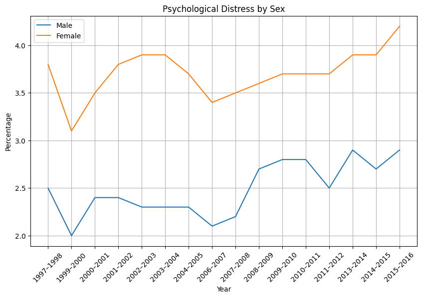

```python
plt.figure(figsize=(10, 6))

for sex in distress_by_sex['sex'].unique():
    subset = distress_by_sex[distress_by_sex['sex'] == sex]
    plt.plot(subset['year'], subset['percent'], label=sex)

plt.xlabel('Year')
plt.ylabel('Percentage')
plt.title('Psychological Distress by Sex')
plt.legend()
plt.grid(True)
plt.xticks(rotation=45)
plt.show()
```

According to the graphic above, it appears that females experience more psychological distress than males over time.

**Psychological Distress by Age**

I followed a similar procedure to above to extract the dataframe that displays psychological distress by age.

```python
ages = ['18–24 years', '25–44 years', '45–54 years', '55–64 years', '65 years and over']

distress_by_age = pd.melt(distress_by_age, id_vars=['year'],
                       value_vars=ages,
                       var_name='age',
                       value_name='percent')

distress_by_age.head()
```

|  | year | age | percent |
| --- | --- | --- | --- |
| 0 | 1997–1998 | 18–24 years | 2.7 |
| 1 | 1999–2000 | 18–24 years | 2.2 |
| 2 | 2000–2001 | 18–24 years | 2.6 |
| 3 | 2001–2002 | 18–24 years | 2.8 |
| 4 | 2002–2003 | 18–24 years | 2.8 |

I then created a graphic to display PD by age.

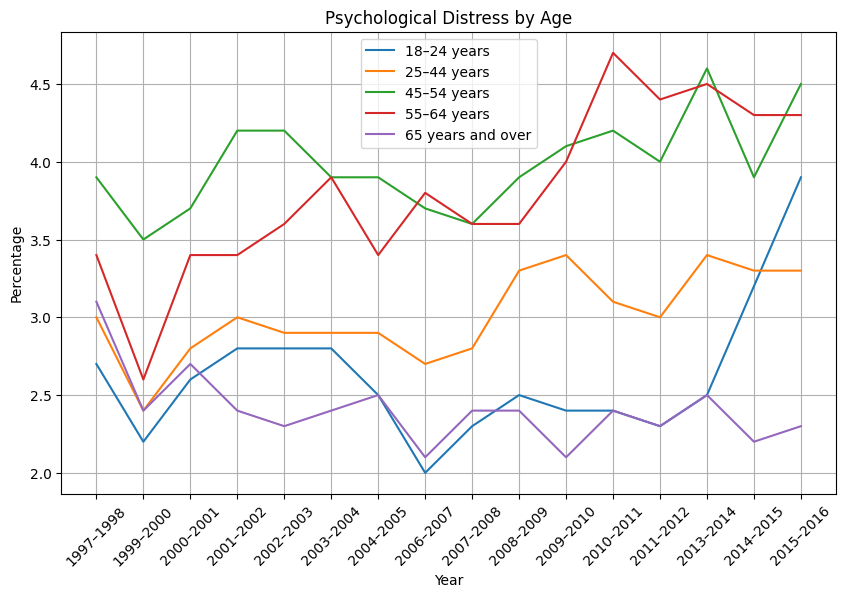

```python
import matplotlib.pyplot as plt

# Assuming 'distress_by_sex' DataFrame is already created as shown in the provided code.

plt.figure(figsize=(10, 6))

for age in distress_by_age['age'].unique():
    subset = distress_by_age[distress_by_age['age'] == age]
    plt.plot(subset['year'], subset['percent'], label=age)

plt.xlabel('Year')
plt.ylabel('Percentage')
plt.title('Psychological Distress by Age')
plt.legend()
plt.grid(True)
plt.xticks(rotation=45)
plt.show()
```

I began by removing the unwanted years from the 'distress_by_age' dataframe.

```python
# Years to remove
years_to_remove = ['1997–1998', '1999–2000', '2000–2001', '2001–2002', '2002–2003', '2003–2004', '2004–2005']

# Create a new dataframe without the specified years
new_distress_by_age = distress_by_age[~distress_by_age['year'].isin(years_to_remove)]

new_distress_by_age.head()
```

|  | year | age | percent |
| --- | --- | --- | --- |
| 7 | 2006–2007 | 18–24 years | 2 |
| 8 | 2007–2008 | 18–24 years | 2.3 |
| 9 | 2008–2009 | 18–24 years | 2.5 |
| 10 | 2009–2010 | 18–24 years | 2.4 |
| 11 | 2010–2011 | 18–24 years | 2.4 |

1. PD percentage by age group over time
2. Female intentional injuries by age group over time
3. Male intentional injuries by age group over time

```python
# 1. Psychological distress percentage by age group over time

for age in new_distress_by_age['age'].unique():
    subset = new_distress_by_age[new_distress_by_age['age'] == age]
    plt.plot(subset['year'], subset['percent'], label=age)

plt.xlabel('Year')
plt.ylabel('Percentage')
plt.title('Psychological Distress by Age')
plt.legend()
plt.grid(True)
plt.xticks(rotation=45)

plt.show()
```

[output not shown]

```python
# 1. Psychological distress percentage by age group over time

for age in new_distress_by_age['age'].unique():
    subset = new_distress_by_age[new_distress_by_age['age'] == age]
    plt.plot(subset['year'], subset['percent'], label=age)

plt.xlabel('Year')
plt.ylabel('Percentage')
plt.title('Psychological Distress by Age')
plt.legend()
plt.grid(True)
plt.xticks(rotation=45)
# plt.tight_layout()
plt.show()

# 2. Female intentional injuries by age group over time

# Function to filter the data for females and a specific injury type, excluding 'all ages'
def filter_data(injury_type):
    return injuries[(injuries['sex'] == 'female') &
                    (injuries['injury type'] == injury_type) &
                    (injuries['age'] != 'all ages')]

# Function to group data by year and age, and select relevant age columns
def group_data(df):
    return df.groupby(['year', 'age'])['number of injuries'].sum().unstack().reindex(columns=['under 18 years', '18–24 years', '25-44 years', '45-64 years', '65 years and over'])

# Injury type for the plot
injury_type = 'intentional injuries'

# Filter and group the data
filtered_df = filter_data(injury_type)
grouped_df = group_data(filtered_df)

# Plotting
x_axis = grouped_df.index
y_axis_columns = grouped_df.columns

plt.figure(figsize=(9, 6))  # Adjust figure size as needed

for column in y_axis_columns:
    y_axis = grouped_df[column]
    plt.plot(x_axis, y_axis, label=column)

plt.xlabel('Year')
plt.ylabel('Number of Injuries')
plt.title(f'Number of Injuries from Intentional Injuries in Females by Age Group')
plt.legend()
plt.grid(True)
plt.xticks(rotation=45) # Rotate x-axis labels for better readability

# 3. Male intentional injuries by age group over time

# Function to filter the data for females and a specific injury type, excluding 'all ages'
def filter_data(injury_type):
    return injuries[(injuries['sex'] == 'male') &
                    (injuries['injury type'] == injury_type) &
                    (injuries['age'] != 'all ages')]

# Function to group data by year and age, and select relevant age columns
def group_data(df):
    return df.groupby(['year', 'age'])['number of injuries'].sum().unstack().reindex(columns=['under 18 years', '18–24 years', '25-44 years', '45-64 years', '65 years and over'])

# Injury type for the plot
injury_type = 'intentional injuries'

# Filter and group the data
filtered_df = filter_data(injury_type)
grouped_df = group_data(filtered_df)

# Plotting
x_axis = grouped_df.index
y_axis_columns = grouped_df.columns

plt.figure(figsize=(9, 6))  # Adjust figure size as needed

for column in y_axis_columns:
    y_axis = grouped_df[column]
    plt.plot(x_axis, y_axis, label=column)

plt.xlabel('Year')
plt.ylabel('Number of Injuries')
plt.title(f'Number of Injuries from Intentional Injuries in Males by Age Group')
plt.legend()
plt.grid(True)
plt.xticks(rotation=45) # Rotate x-axis labels for better readability
```

[output not shown]

# **5. Probability Model Evaluation**

To create this classification model, I began by ensuring I had all of the necessary libraries.

```python
import pandas as pd
from sklearn.naive_bayes import MultinomialNB
from sklearn.model_selection import train_test_split
from sklearn.preprocessing import LabelEncoder
from sklearn.preprocessing import KBinsDiscretizer
```

Next, I assigned numerical values to each age group for simplicity.

```python
age_mapping = {
    'under 18 years': 0,  # Assign numerical values to each age group
    '18–24 years': 1,
    '25-44 years': 2,
    '45-64 years': 3,
    '65 years and over': 4
}

# Replace age group strings with numerical values in the 'age' column
injuries['age_numeric'] = injuries['age'].map(age_mapping)
```

I then ensured no NaNs existed in my 'injuries' dataframe and discretized the new 'age_numeric' column that now contains numerical values rather than object values.

```python
# Remove any stray NaNs
injuries.dropna(inplace=True)

# Discretize the 'age_numeric' column (now containing numerical values)
scaler = KBinsDiscretizer(n_bins=4, encode='ordinal', strategy='uniform')
injuries['age_binned'] = scaler.fit_transform(injuries[['age_numeric']])
```

Further, I encoded the categorical values 'sex' and 'injury_type' in preparation for defining the input and target values. From here, I split the data into training and testing sets.

```python
# Encode categorical variables ('sex' and 'injury_type')
le_sex = LabelEncoder()
injuries['sex_encoded'] = le_sex.fit_transform(injuries['sex'])

le_injury = LabelEncoder()
injuries['injury_type_encoded'] = le_injury.fit_transform(injuries['injury type'])

# Features (age_binned and sex_encoded) and target (injury_type_encoded)
X = injuries[['age_binned', 'sex_encoded']]
y = injuries['injury_type_encoded']

# Split data into train and test sets
X_train, X_test, y_train, y_test = train_test_split(X, y, test_size=0.2, random_state=42)
```

To remove any unwanted text from my outputs, I imported the 'warnings' library and ignored all warnings.

```python
import warnings

# Ignore all warnings
warnings.filterwarnings("ignore")
```

Further, I initialized and trained my model.

```python
# Initialize and train the Multinomial Naive Bayes model
model = MultinomialNB()
model.fit(X_train, y_train)
```

**Example: Male between the age of 25 and 44 years old**

To calculate the injury mechanism probabilities for this random male, I input '2' for the 'age_binned' which is used to encode '25-44 years' and 'male' for 'age_encoded'. I then predict the probabilities and add the injury types as variable labels for easier visualization.

```python
# For the new individual, we need to encode the data the same way:
new_data_1 = pd.DataFrame({'age_binned': [scaler.transform([[2]])[0][0]],  # '2' is the age bin for 25-44 years
                         'sex_encoded': [le_sex.transform(['male'])[0]]})

# Predict probabilities for each injury type
probabilities = model.predict_proba(new_data_1)

# Assign column titles to the probabilities dataframe
predictions = pd.DataFrame(probabilities, columns= ['Unintentional injuries','Falls','Struck','Motor vehicle traffic','Cut or pierce','Intentional injuries'])

# Output the probabilities
predictions
```

[output not shown]

# **6. Conclusion**

Understanding the relationships that exist between injury mechanisms and age/sex can better inform individuals when making decisions about their person safety. From this data analysis, I observed that:

- Females ages 65 and over are more frequently injured from falling.
- Females under 18 years of age are more frequently injured from being struck by or against object or people.
- Females aged between 25 and 44 years are more frequently injured from motor vehicle accidents, being cut or pierce, and intentional injuries.
- Males under the age of 18 were more frequently injured by falls and being stuck by or against object or people.
- Males between the ages of 25 and 44 years old were more frequently injured by motor vehicle traffic accidents, being cut or pierce, or intentional harm.

Interestingly, both males and females between the age of 25-44 years were more frequently injured by intentional harm. As a consequence, for example, we can provide individuals within this age group, whether they are male or female, promotive mental health resources and support.

**Drawbacks and Further Directions**

If I were to have more time for this project, I would find a clear dataset describing depression rates over time in the past 2 decades. I would also like to bring in datasets that describe injury rates and mechanisms by state to perhaps see which state is the most safe or unsafe.

```python
from google.colab import drive
drive.mount('/content/drive')
```

```python
%%shell
jupyter nbconvert --to html '/content/drive/MyDrive/CMPS 6160/Final Project/Final Notebook.ipynb'
```